# How Americans Spend Time with Pets

Catherine Hayden

1/22/2020

# The American Time Use Survey

The American Time Use Survey administered by the Bureau of Labor Statistics provides a comprehensive look into the daily activities of Americans. The survey looks at activities from time spent doing laundry, doing homework, using legal services to time spent with pets. This analysis will focus primarily on the individuals that reported time spent with pets and how they differ in terms of demographics and spending time from those who did not report spending time with pets.

[figure not shown]

# Demographic Insights

*Pet owners by family income*

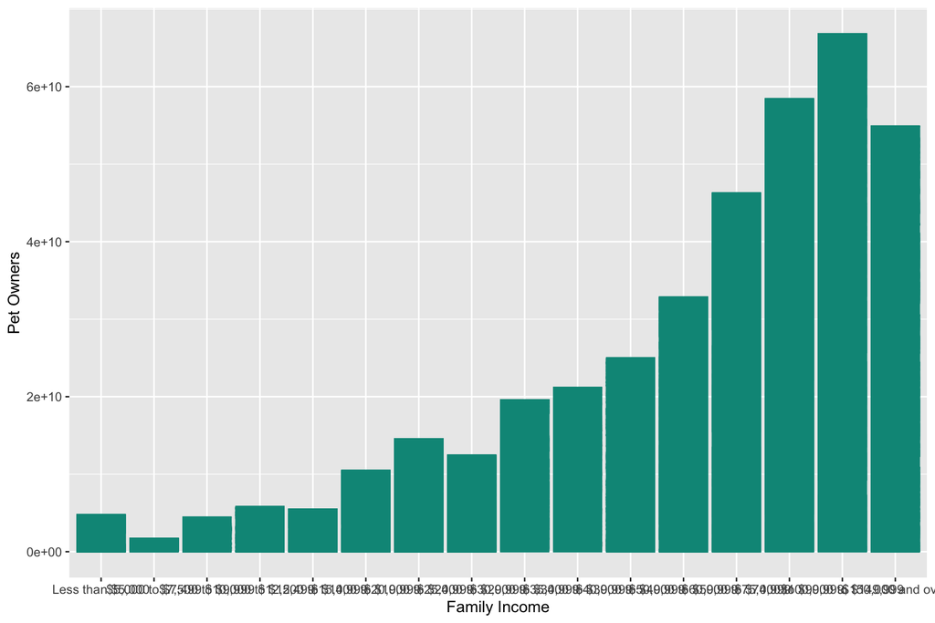

It appears that there are far more pet owners with higher family incomes. The income bracket with the highest population of pet owners is from $100,000 to 149,999 dollars.

*Number of pet owners by region*

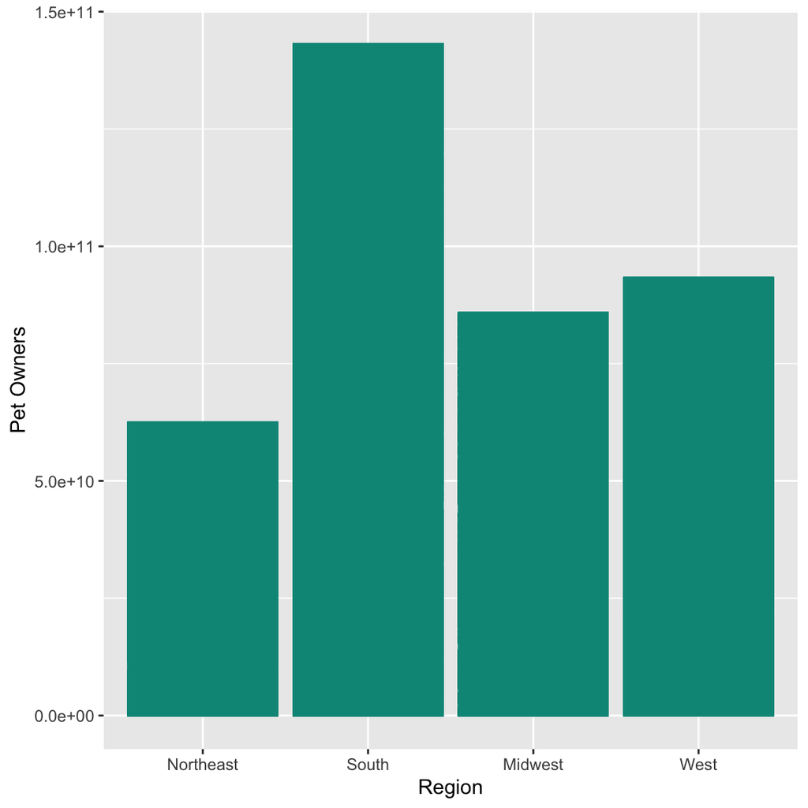

The South is most heavily populated with pet owners, while the Northeast is the least.

*Pet owners by type of region*

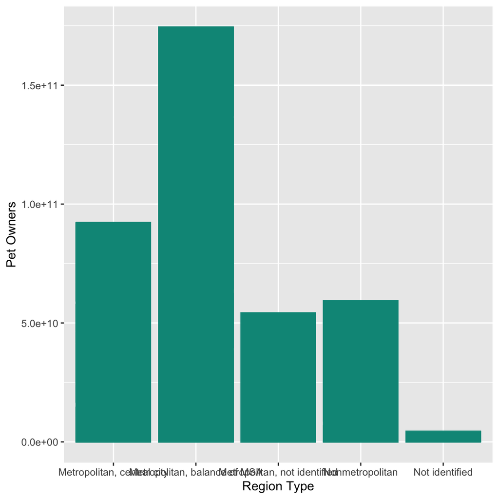

*Pet owners by education level*

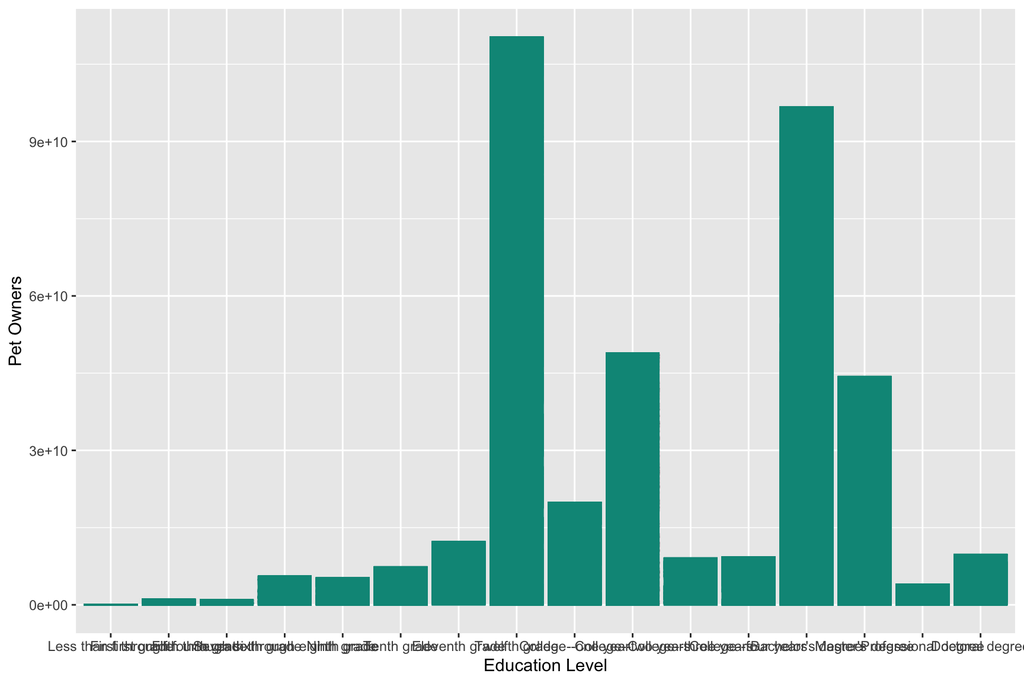

The majority of pet owners are individuals with high school and undergraduate degrees, however this distribution is not likely to be unique to pet owners.

*Pet owners by home ownership status*

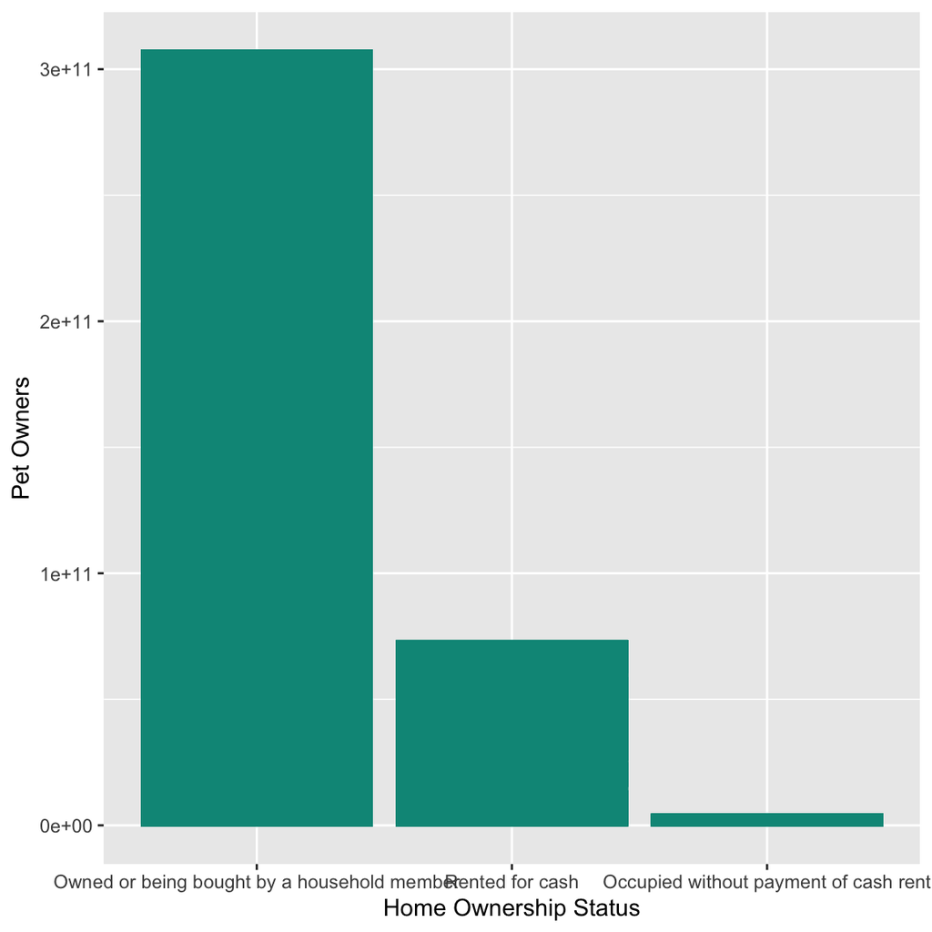

Most pet owners are homeowners as well. This relationship is relatively intuitive due to the limitations of owning a pet in most rental properties.

# Demographics of Time Spent with Pets

*Histogram of duration time spent with pets*

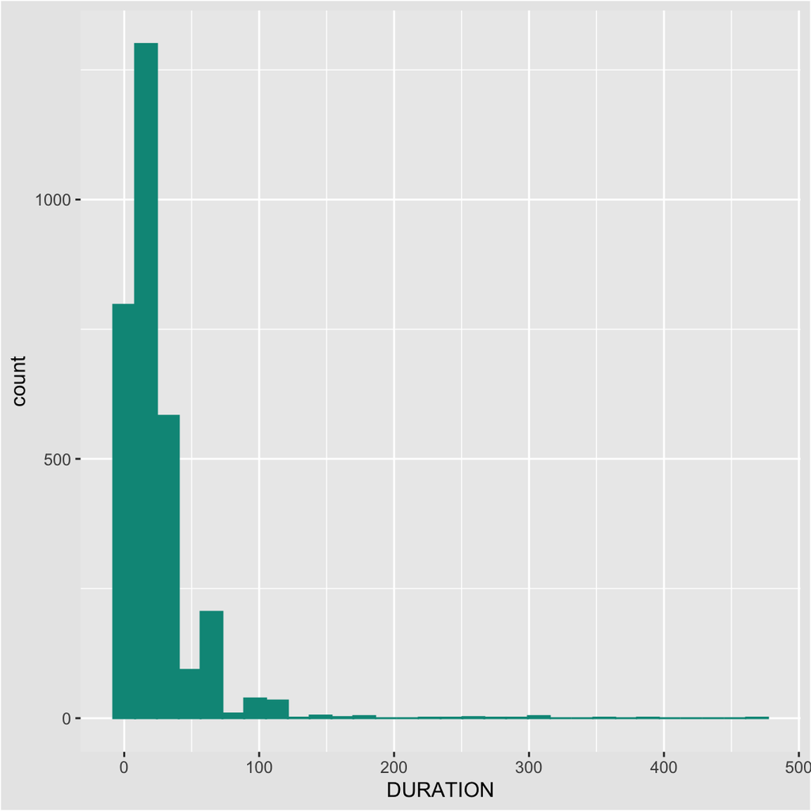

*Time with pets by day of the week*

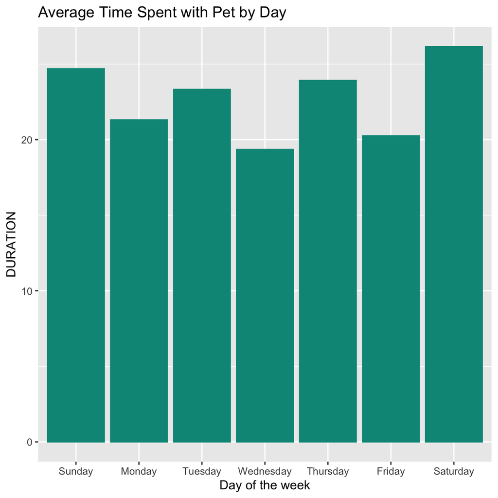

*Time with pets by Family Income*

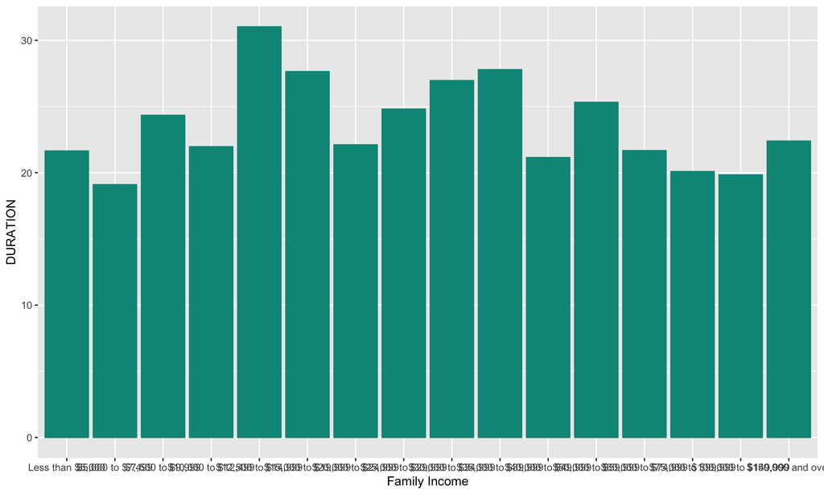

There doesn’t appear to be a relationship between time spent with pets and family income.

*Time with pets by Education*

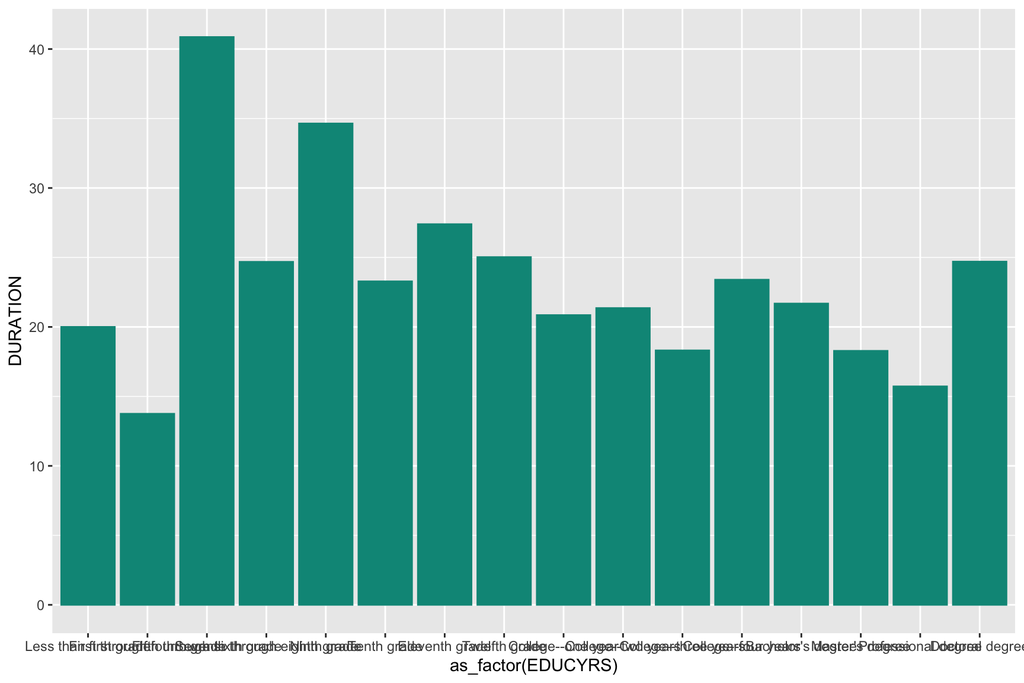

*Tine with pets by Sex*

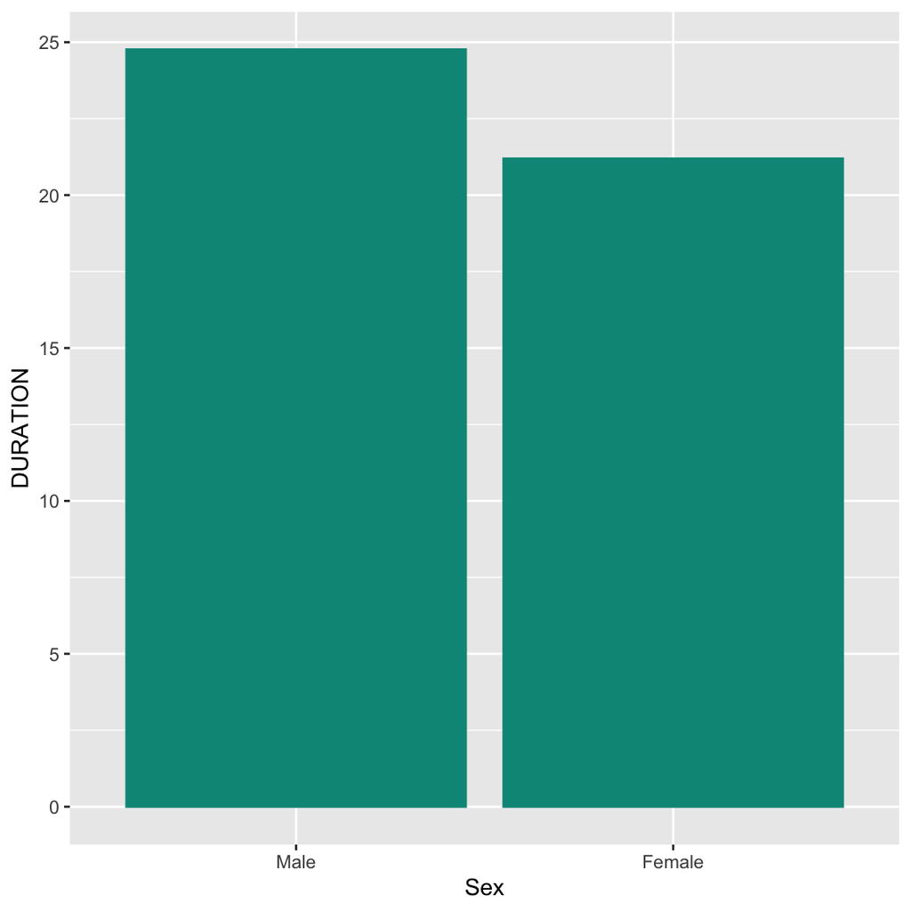

*Two Sample t-test: difference in time spent with pets across sexes?*

```
##
##  Welch Two Sample t-test
##
## data:  time_bysex$"1" and time_bysex$"2"
## t = 3.70762182522, df = 1629.90871128, p-value = 0.00021621803698
## alternative hypothesis: true difference in means is not equal to 0
## 95 percent confidence interval:
##  2.1366571981621 6.9366573078447
## sample estimates:
##       mean of x       mean of y
## 25.626893939394 21.090236686391
```

There is very strong evidence that males spent more time with pets than females (p-value: 0.000*) 95% CI:(2.14, 6.94)

*Time with pets by Age*

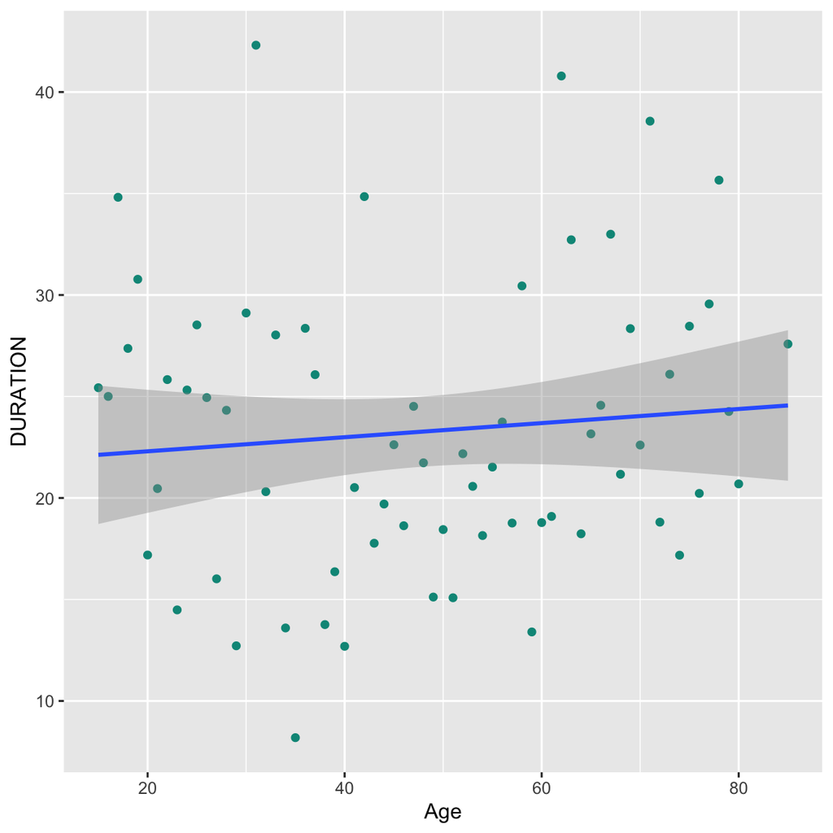

```
##
## Call:
## lm(formula = DURATION ~ Age, data = pet_act)
##
## Coefficients:
##     (Intercept)              Age
## 20.631229401517   0.037362521978
```

There is a slight relationship between age and time spent with pets. As age increases by 1 year, duration increases by 0.0374 minutes. (no test for significance)

# Zooming in on Various Pet Activities

*Comparing frequency of different pet activities using pet_act(dataset excluding non-pet activity observations)*

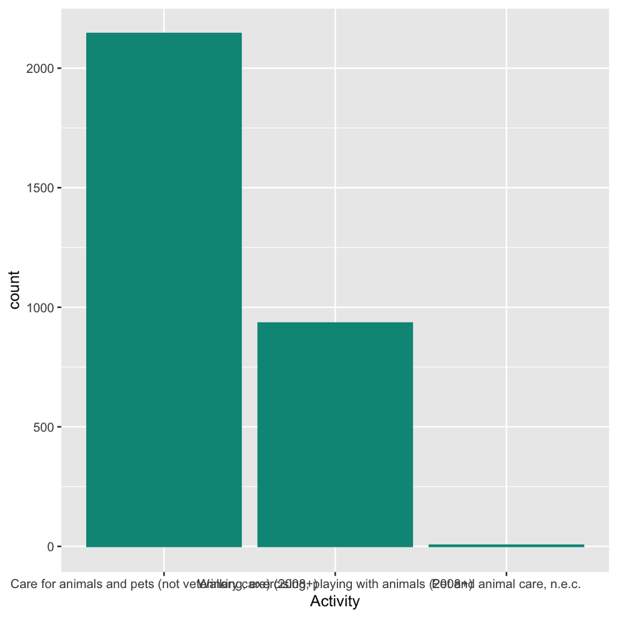

The vast majority of reported activities with pets involved care for animals and pets.

*Weighted mean duration by pet related activity*

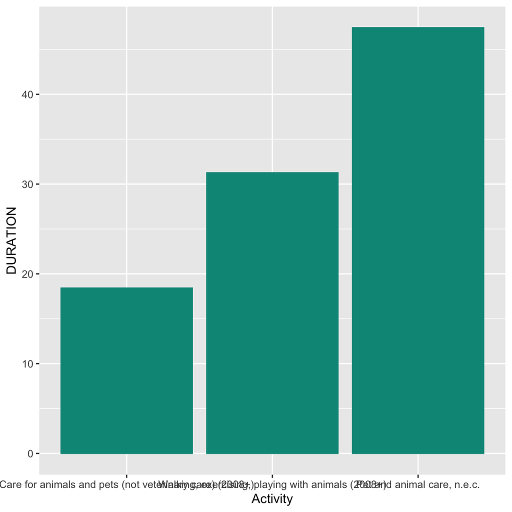

The majority of time respondents spent with pets involved pet and animal care.

*Where do people spend time with pets?*

Weighted mean of duration by location of activity

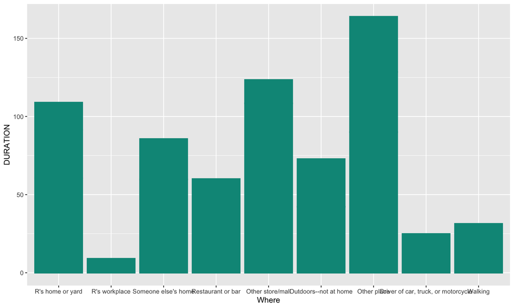

The top three locations for Americans to spend time with pets are “other place”, at the store or mall, and at home.

*Weighted mean of duration by location of activity across different pet activities*

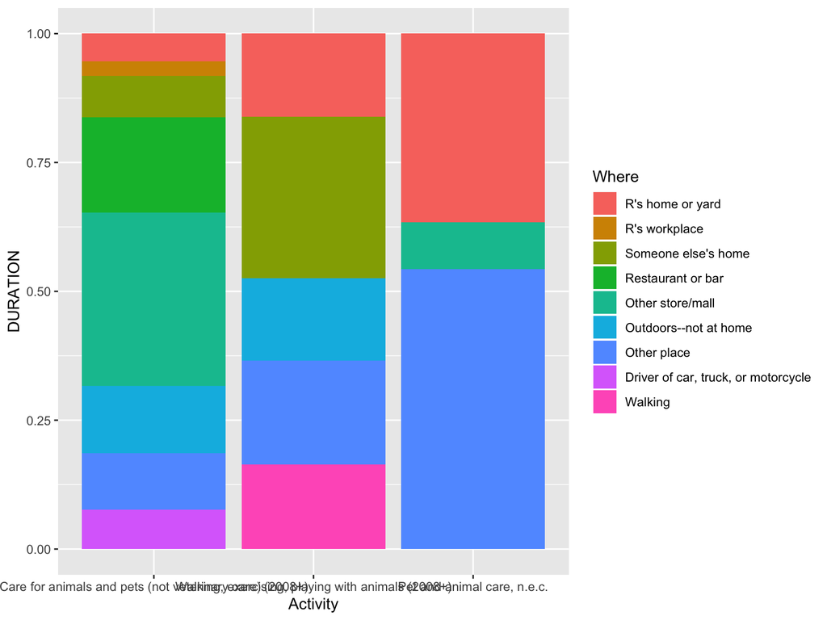

# What Differs between Pet Owners and others?

*Family Income by Pet Ownership*

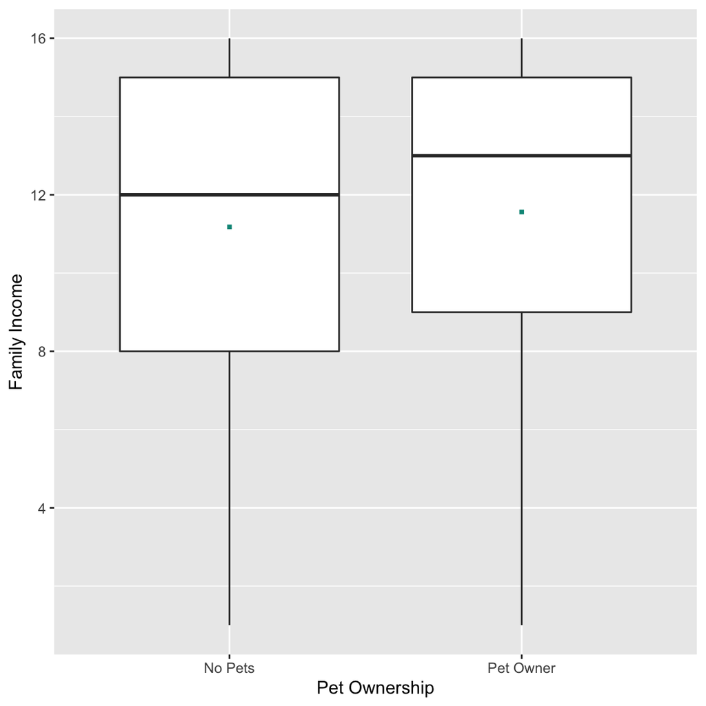

Pet owners appear to have a slightly higher mean and median family income than individuals with no pets.

*Education by Pet Ownership*

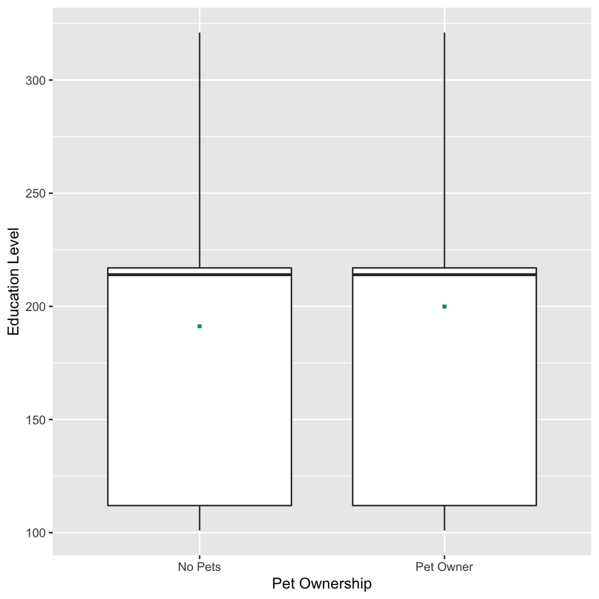

There doesn’t appear to be much difference in Education between pet owners and non pet owners.

# Exploring connections to mental health and wellbeing

The following comparisons may have significance in the discussion of correlation between pet ownership and mental health.

*Sleeplessness by Pet Ownership*

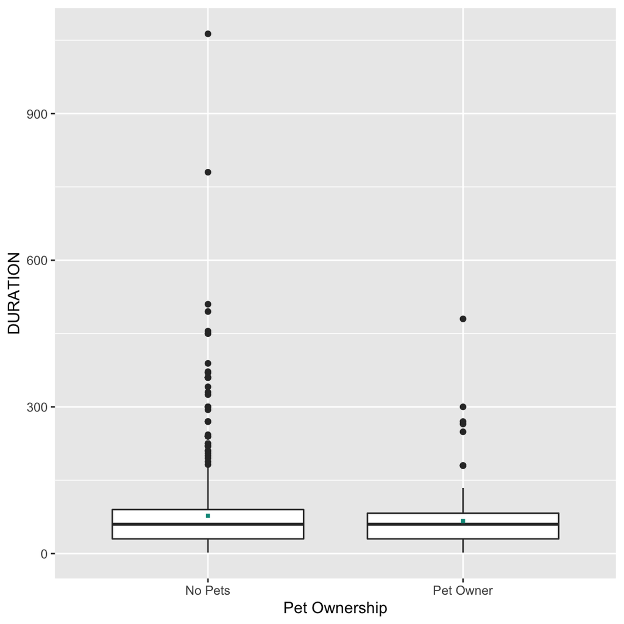

*Two sample t-test comparing sleeplessness by pet ownership*

```
##
##  Welch Two Sample t-test
##
## data:  sleeplessness$"0" and sleeplessness$"1"
## t = 1.70011340907, df = 311.657792077, p-value = 0.090107247053
## alternative hypothesis: true difference in means is not equal to 0
## 95 percent confidence interval:
##  -1.6715625812336 22.9196840888429
## sample estimates:
##       mean of x       mean of y
## 78.288490284006 67.664429530201
```

With a p-value of 0.09, there is no evidence of a difference in time spent sleepless on average between pet owners and non pet owners at an alpha level of 0.05. 95% CI: (-1.67, 22.92)

*Histogram of time spent sleepless*

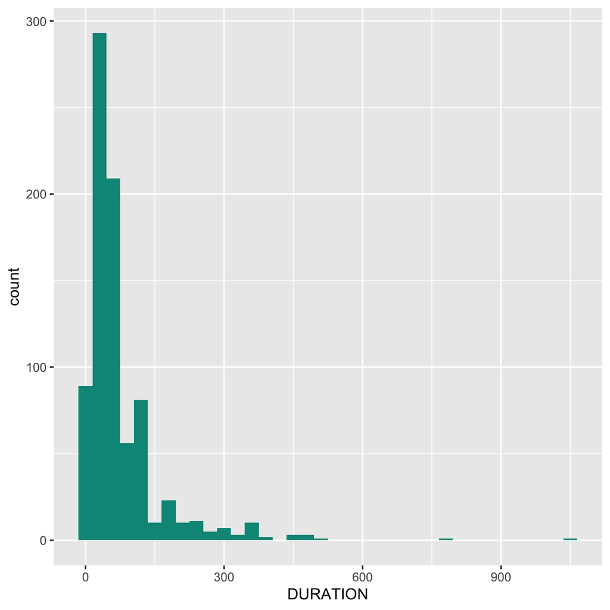

The duration of time spent sleepless across respondents is heavily skewed right, suggesting we may want to transform our data for analysis.

*Log transformed historgram of time spent sleepless*

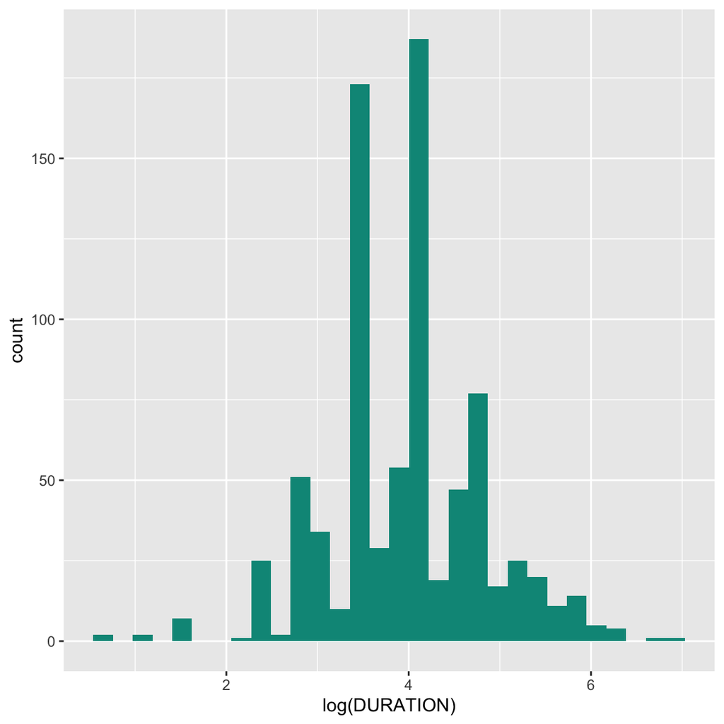

The log transformed data appears less skewed than the original data. Lets see how this impacts our analysis.

```
##
##  Welch Two Sample t-test
##
## data:  sleeplessness_log$`0` and sleeplessness_log$`1`
## t = 0.774788055474, df = 222.333896011, p-value = 0.43928810513
## alternative hypothesis: true difference in means is not equal to 0
## 95 percent confidence interval:
##  -0.094127695030234  0.216092447252706
## sample estimates:
##       mean of x       mean of y
## 3.9445741996956 3.8835918235844
```

The new t-test with log transformed data yields the same results: there is no evidence of a difference in time spent sleepless across pet ownership.

*Time Spent Outdoors by Pet Ownership*

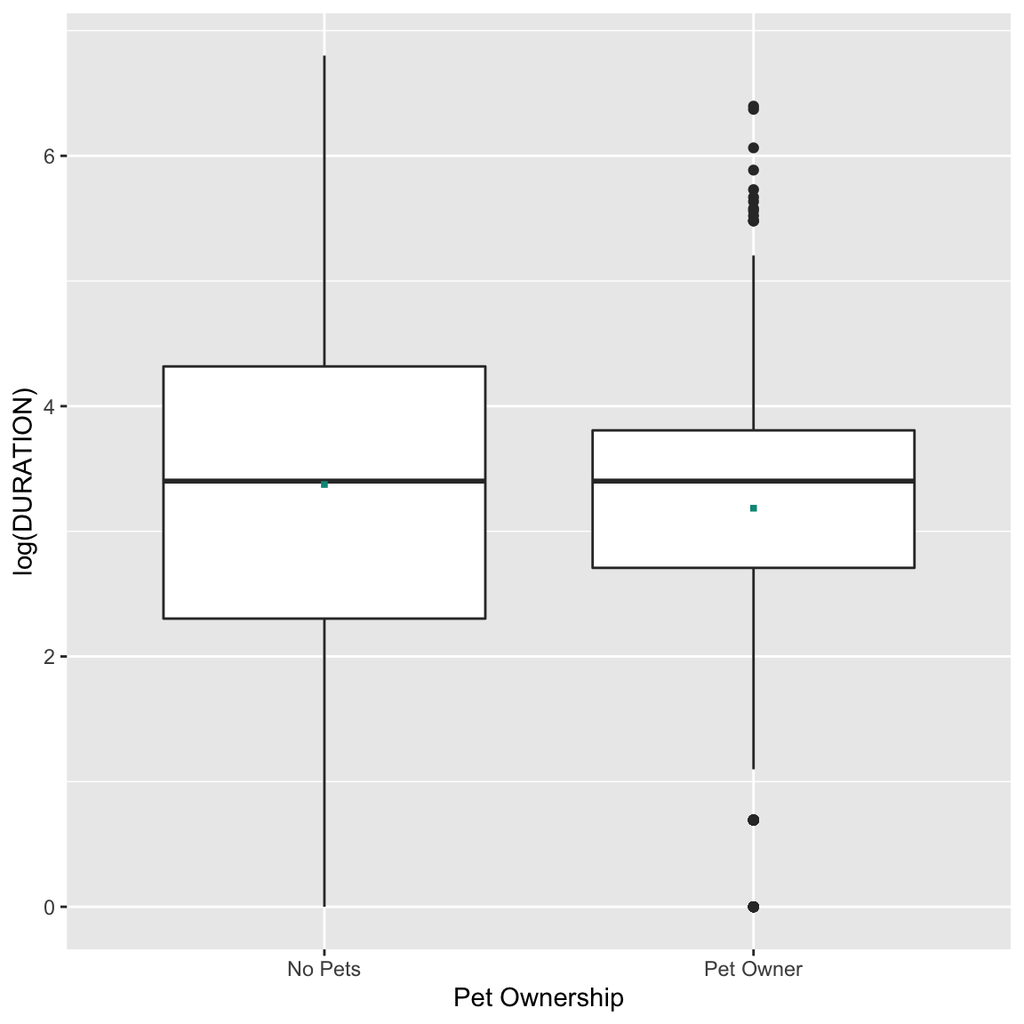

```
##
##  Welch Two Sample t-test
##
## data:  time_outdoors$"0" and time_outdoors$"1"
## t = 8.11439562157, df = 2309.64926334, p-value = 7.8464708355e-16
## alternative hypothesis: true difference in means is not equal to 0
## 95 percent confidence interval:
##  18.136012348423 29.695327613575
## sample estimates:
##       mean of x       mean of y
## 63.577077747989 39.661407766990
```

There is very strong evidence of a difference in time spent outdoors between pet owners and non pet owners (p-value= 0.000*). We can be 95% confident that people without pets spend between 18.13 and 29.70 more minutes outside than their pet owning counterparts.

*Histogram of time spent outdoors*

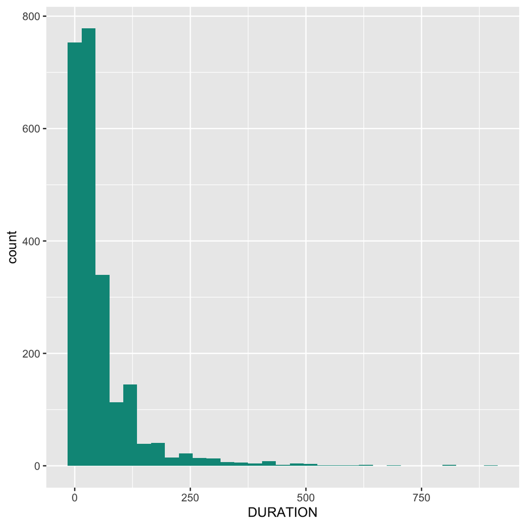

Once again, our data is skewed right.

*Log transformed histogram of time spent outdoors*

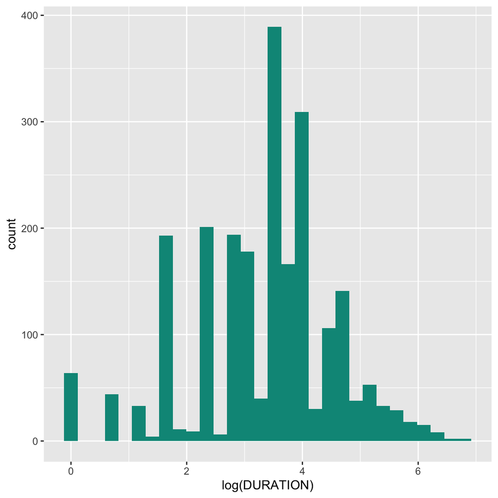

Taking the log of duration of time spent outdoors slightly normalizes the distribution. Let’s take a look at how this transformation affects the two sample t-test…

```
##
##  Welch Two Sample t-test
##
## data:  time_outdoors$"0" and time_outdoors$"1"
## t = 3.74216565296, df = 2099.92308704, p-value = 0.00018733906298
## alternative hypothesis: true difference in means is not equal to 0
## 95 percent confidence interval:
##  0.090246111209557 0.288981706661493
## sample estimates:
##       mean of x       mean of y
## 3.3742217806800 3.1846078717445
```

With the log transformed data, the t-test provides the same results. There is very strong evidence that non pet owners spend more time outside than pet owners (p-value = 0.000*)

*Leisure across pet ownership*

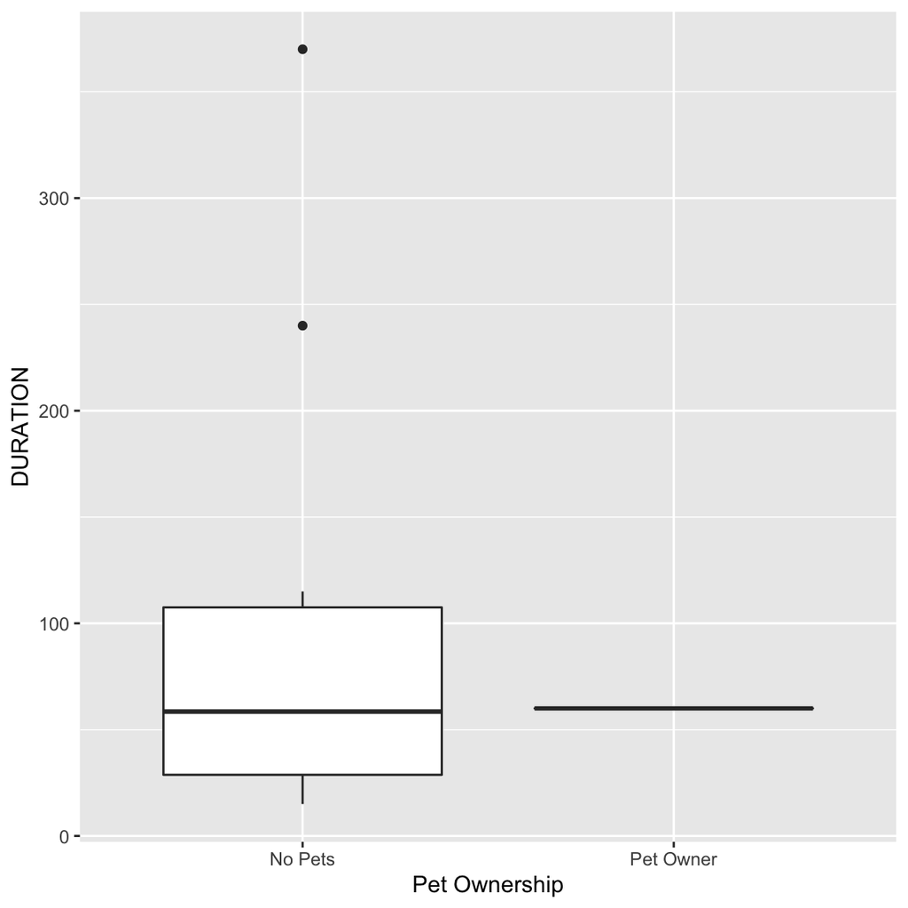

Unfortunately, there is only one data point describing leisure for a respondent that also reported spending time with pets.

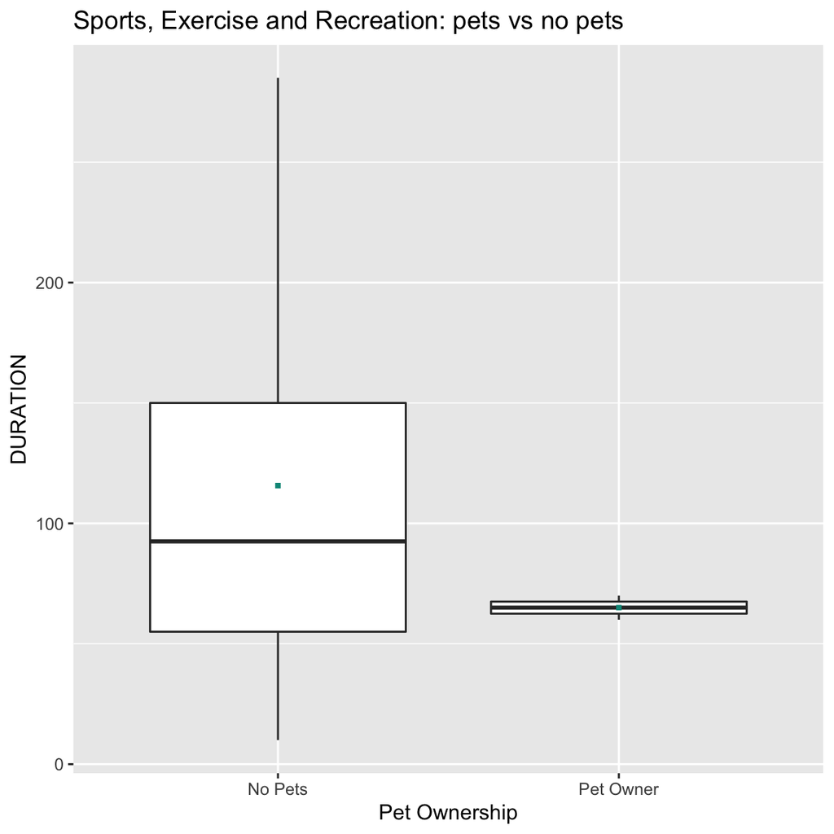

*How many activities do pet owners and non pet owners engage in per day?*

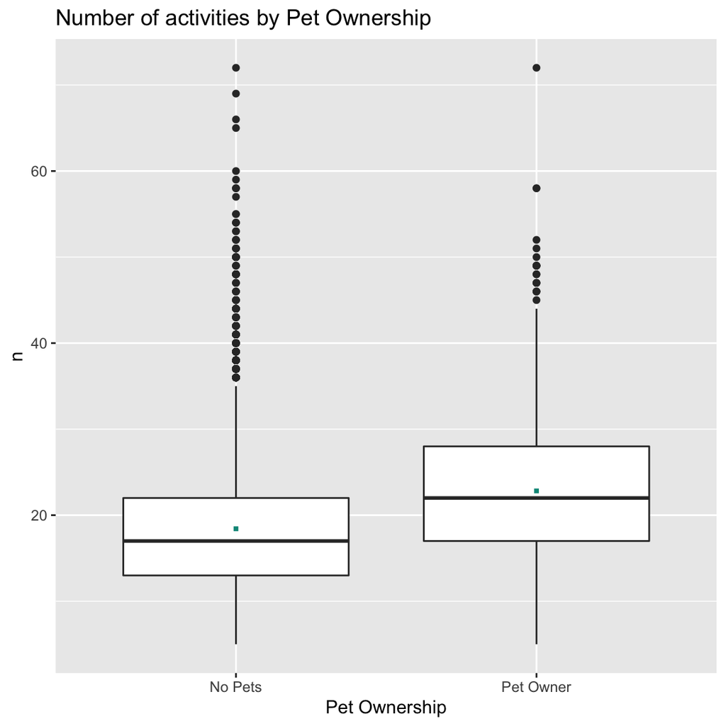

It appears as though pet owners engage in more activities than non pet owners on a daily basis. Lets see if there is a significant difference using a t-test…

```
##
##  Welch Two Sample t-test
##
## data:  act_quant_ttest$"0" and act_quant_ttest$"1"
## t = -20.2759183863, df = 2326.29147395, p-value < 2.22044605e-16
## alternative hypothesis: true difference in means is not equal to 0
## 95 percent confidence interval:
##  -4.8241752079132 -3.9733254424093
## sample estimates:
##       mean of x       mean of y
## 18.423339227078 22.822089552239
```

There is very strong evidence that pet owners engage in more activities than non pet owners on average (p-value = 0.000*). 95% CI: (-4.82, -3.97)

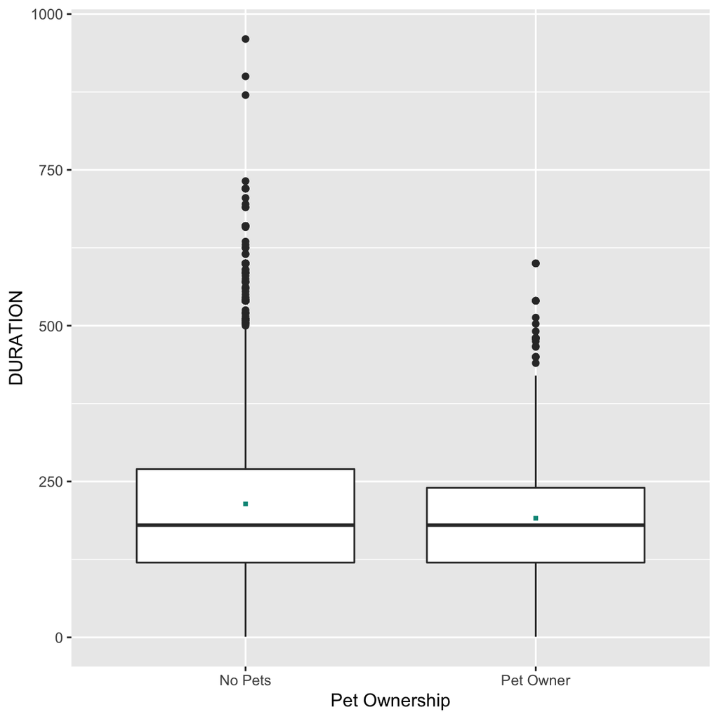

[output not shown]

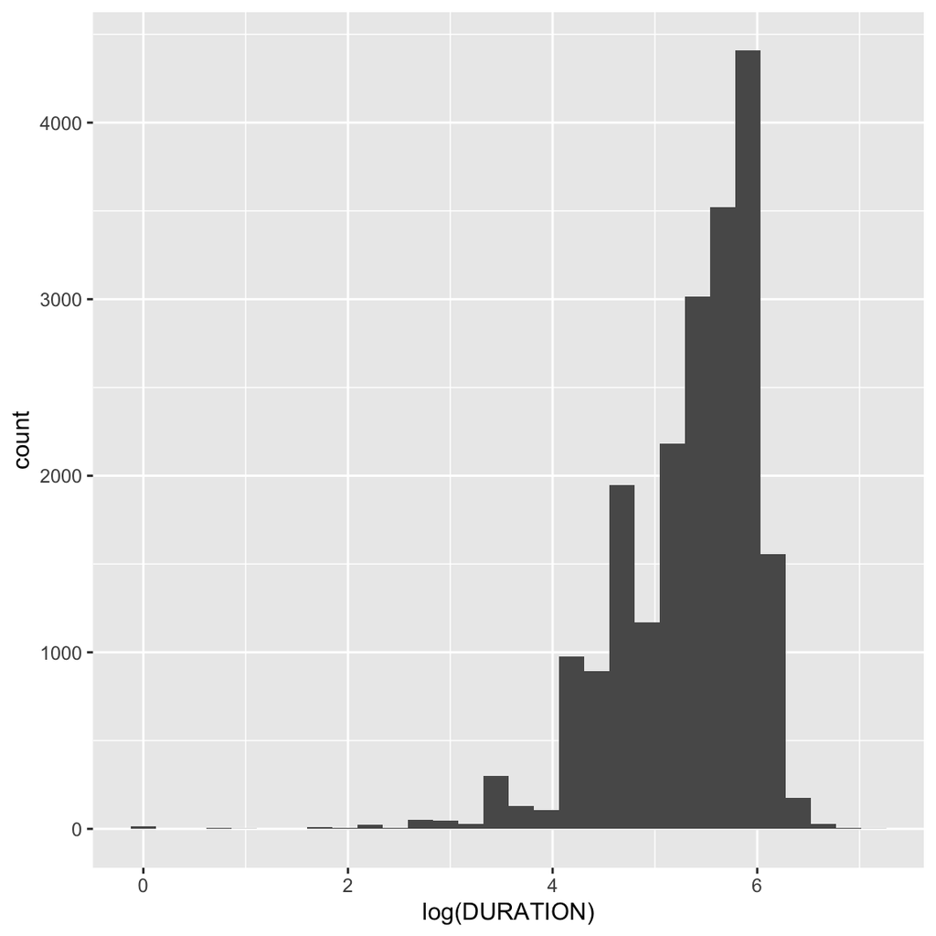